# Corona - Fallzahlenauswertung

### Datenquelle, Abrufzeitpunkt

| Amtliche RKI-Corona-Daten für Land-/Stadtkreis | Abrufzeitpunkt |
| --- | --- |
| Traunstein, Landkreis | Montag, 15.03.2021, 15:37:14 |

[Link zur Datenbeschreibung des RKI](https://www.arcgis.com/home/item.html?id=dd4580c810204019a7b8eb3e0b329dd6)

### Inzidenzrelevanter Zeitraum

| von - bis | nicht mehr in der Inzidenzzahl |
| --- | --- |
| Mo, 08.03.2021 - So, 14.03.2021 | So, 07.03.2021 und älter |

### Veränderungen zum Vortag

```
##   Meldedatum Art Inzidenzrelevant Fallzahl A00-A04 A05-A14 A15-A34 A35-A59 A60-A79
## 1 2021-03-13 Neu               Ja        9       1      NA       4       3       1
## 2 2021-03-14 Neu               Ja       41       1       3      18      14       5
```

### Wochenübersicht

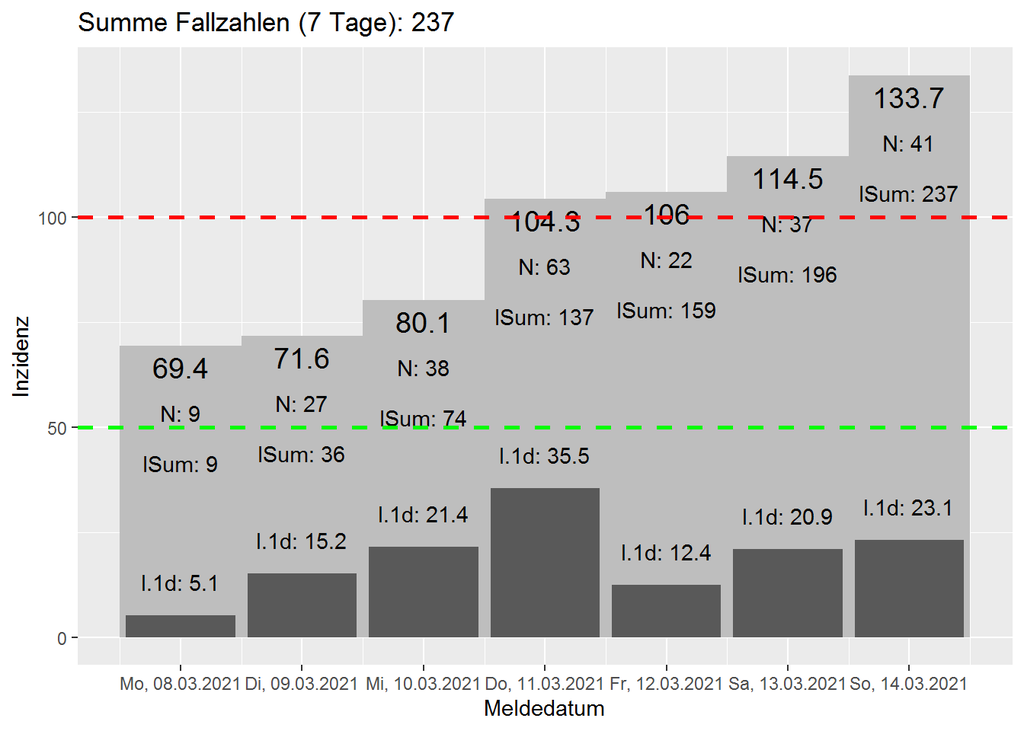

Erläuterung der Zahlenangaben:  
**N**: Anzahl der neu und nachträglich gemeldeten abzüglich der gestrichenen Fälle des jeweiligen Tages  
**I.1d** (“1-Tages-Inzidenz”): Höhe des Beitrags, den dieser Tag zur Wocheninzidenz leistet  
**lSum**: Aggregierte Summe der Fallzahlen über den Verlauf der beobachteten Woche. Der erste Tag entspricht diesem einzelnen Tag (und fällt als nächstes aus der Inzidenz), der letzte Tag entspricht der Wochen-Inzidenz.

### Über-/Unterschreitungen der geltenden Grenzwerte

```
##   Grenzwert bei_Fallzahl Abweichung
## 1        50           88       +149
## 2       100          177        +60
```

### Gesicherter Ausblick (absehbare Streichungen)

Aktuelle Inzidenz: 133.7, basierend auf den insgesamt 237 Fällen der letzten Woche.

[output not shown]

Die Fallzahlen der nächsten Tage sowie eventuelle Nachmeldungen sind dabei nicht vorhersehbar. Der maximale Rückgang wird nur erreicht, wenn bis zu diesem Tag per Saldo kein neuer Fall erfasst wird.

### Ungesicherter Ausblick

Fallzahlen gehen je nach Wochentag in unterschiedlicher Höhe ein. Basierend auf den letzten 3 Wochen bzw. 21 Tagen ergibt sich folgende Verteilung:

```
##    Wochentag Fallzahl_Durchschnitt DoW
## 1    Sonntag                 24.33   1
## 2     Montag                  5.00   2
## 3   Dienstag                 19.33   3
## 4   Mittwoch                 25.67   4
## 5 Donnerstag                 34.00   5
## 6    Freitag                 19.00   6
## 7    Samstag                 25.67   7
```

…auf der Grundlage folgender Fallzahlen der letzten 3 Wochen:

```
##    Meldedatum AnzahlFall  Wochentag
## 1  2021-02-22          5     Montag
## 2  2021-02-23          8   Dienstag
## 3  2021-02-24         16   Mittwoch
## 4  2021-02-25         19 Donnerstag
## 5  2021-02-26         16    Freitag
## 6  2021-02-27         18    Samstag
## 7  2021-02-28         25    Sonntag
## 8  2021-03-01          1     Montag
## 9  2021-03-02         23   Dienstag
## 10 2021-03-03         23   Mittwoch
## 11 2021-03-04         20 Donnerstag
## 12 2021-03-05         19    Freitag
## 13 2021-03-06         22    Samstag
## 14 2021-03-07          7    Sonntag
## 15 2021-03-08          9     Montag
## 16 2021-03-09         27   Dienstag
## 17 2021-03-10         38   Mittwoch
## 18 2021-03-11         63 Donnerstag
## 19 2021-03-12         22    Freitag
## 20 2021-03-13         37    Samstag
## 21 2021-03-14         41    Sonntag
```

### Blick in die Kristallkugel

Hier werden drei verschiedene Szenarien dargestellt:  
* Optimistische Variante 0 (Grün): Es treten keine Fälle mehr auf, somit dauert es noch 7 Tage, bis alle Inzidenzfälle abgeschmolzen sind.  
* Realistische Variante 1 (schwarz): Täglich kommen die durchschnittlichen Fälle für den jeweiligen Wochentag hinzu, was dem Abschmelzen aus Variante 0 entgegenwirkt.  
* Pessimistische Variante 2 (Rot): Wie Variante 1, nur kommt täglich der DOPPELTE Durchschnitt für den jeweiligen Wochentag hinzu. Dieser Zuwachs stellt keineswegs das obere Limit des möglichen dar.

**Bitte beachten: Im Folgenden stellt die Zeitachse das Veröffentlichungsdatum dar, nicht das Meldedatum, und ist somit um einen Tag verschoben!**

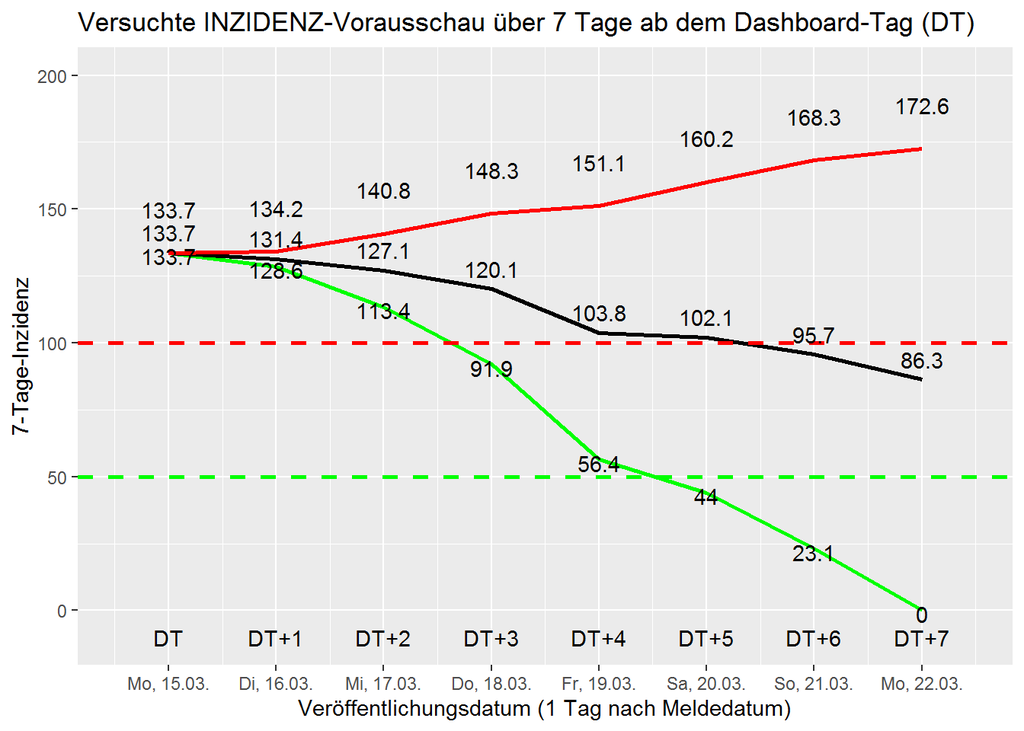

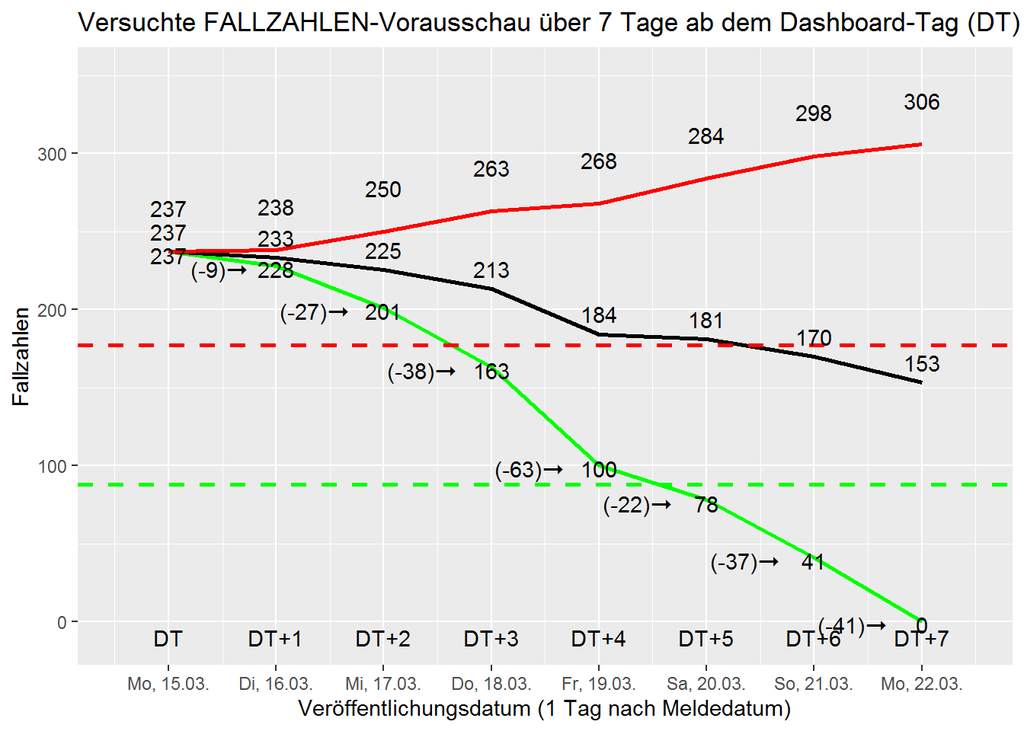